# Estimación de participación en el Conteo Rápido

```r
library(cmdstanr)
library(posterior)
library(tidyverse)
library(patchwork)
source("../R/simular_resumenes.R")
```

### Problema

Para dar resultados en la noche de las elecciones, el INE diseña y selecciona una muestra de casillas de las que se recogen los datos en cuanto la casilla cierra. De esta manera no es necesario esperar a que todos los datos sean registrados y validados para dar los resultados finales, lo cual puede tomar varios días.

En este caso buscamos estimar la participación nacional (porcentaje de votantes registrados que emitió su voto) con los datos de la muestra de casillas.

### Análisis conceptual

El diseño de la muestra es estratificado, con tamaño de muestra proporcional al tamaño de cada estrato. Se dicidió muestrar 5% de las casillas de cada estrato.

Los estratos son principalmente dados por distritos electorales, aunque algunos distritos más chicos se unen para tener un mínimo de casillas especificado:

- Los estratos son distritos electorales.
- Cada distrito electoral incluye varias casillas.
- El tamaño de los estratos se mide con el número de casillas en todo el estrato.

Para este ejemplo **no** consideraremos las casillas especiales, que no tienen una lista nominal definida. Aunque son una proporción considerablemente chica de los votos, podríamos tratarlos más adelante de otra forma.

El marco muestral es el listado de todas las casillas. En este ejemplo usaremos datos de un solo estado.

```r
load("../datos/marco_nal_2018.rda")
marco_tbl <- marco_nal_2018 %>%
  filter(ln > 0) %>%
  filter(id_estado == 9) %>%
  group_by(estrato) %>%
  mutate(estrato_id = group_indices()) %>%
  arrange(estrato_id) %>%
  ungroup %>%
  mutate(casilla_id = row_number()) %>%
  select(id, casilla_id, estrato_id, ln)
```

[output not shown]

```r
marco_tbl
```

| id | casilla_id | estrato_id | ln |
| --- | --- | --- | --- |
| 9-821-1-B-0 | 1 | 1 | 575 |
| 9-821-1-C-0 | 2 | 1 | 575 |
| 9-821-2-C-0 | 3 | 1 | 575 |
| 9-821-3-C-0 | 4 | 1 | 575 |
| 9-822-1-B-0 | 5 | 1 | 726 |
| 9-822-1-C-0 | 6 | 1 | 726 |
| 9-822-2-C-0 | 7 | 1 | 725 |
| 9-823-1-B-0 | 8 | 1 | 678 |
| 9-823-1-C-0 | 9 | 1 | 678 |
| 9-823-2-C-0 | 10 | 1 | 678 |

[output cut: 990 more lines]

Tenemos información de:

- Localización de la casilla (estrato, estado)
- Tamaño de la lista nominal en cada casilla.
- Si la casilla está en una zona rural o no.

Este es un problema de muestreo para población finita, y lo enfocamos de esa manera:

- Tenemos, para la muestra, número de votos que se emitieron y tamaño de la lista nominal ($y_i$, $n_i$), cuando $i\in S$
- A partir de estos datos, queremos estimar $y_i$ con $\hat{y}_i$ para $i\notin S$
- Estimaremos la participación como
  $$\frac{\sum_{i\in S} y_i + \sum_{i\notin S} y_i}{\sum_i n_i}$$
  Tenemos incertidumbre porque no observamos las $y_i$ fuera de la muestra.

Históricamente, las participación en elecciones presidenciales en México ha oscilado entre el 40% y el 77% desde 1988 hasta 2020 (**referencia**)

Algunas casillas especiales no tiene lista nominal fija. Estas casillas serán excluídas del cálculo, aunque quisiéramos reportar también estimaciones del total de votos emitidos

### Espacio de observaciones

Las observaciones están dadas por conteos de las casillas en la muestra del número total de votos.

```r
data {
  // datos fijos
  int num_estratos;
  int n_est[num_estratos]; // num casillas por estrato
  int N; // num casillas total
  int m_nominal[N]; // tamaño de lista nominal en cada casilla
  int est[N]; // indicador de estrato para cada casilla
  int n; // tamaño de muestra
  int muestra[n]; //indices de casillas en la muestra
  // observaciones
  int y_obs[n]; // conteos en cada casilla de votos totales
}
```

### Estadísticas resumen

Nuestras estadísticas resumen principales son:

- La participación sobre todas las casillas definido arriba
- Participación en cada estado.

### Desarrollo del modelo

Las observación para una casilla particular en la muestra es $y_i$, y suponemos dada la lista nominal $n_i$.

En primer lugar, podríamos considerar que cada casilla $y_i$ es una observación binomial con parámetros $(n_i, p_{est(i)})$, donde $p_{est(i)}$ es la probabilidad de que un votante del estrato $i$ ejerza su voto. En este caso tendríamos que el valor esperado de votos en cada casilla es $n_ip_{est(i)}$ con $n_ip_{est(i)}(1-p_{est(i)})$

Pero esta hipótesis no es realmente creíble, pues:

1. Debe existir heterogeneidad en los votantes en cuanto a su probabilidad de voto, dentro de las casillas.
2. Debe existir heterogeneidad en la probabilidad de que un votante vote a lo largo de las casillas dentro los estratos.

Esta heterogeneidad puede producir que la varianza de las observaciones dentro de cada estrato está más (o menos) dispersa con respecto a lo que esperaríamos con el modelo binomial. Por ejemplo, si en una casilla los votantes se dividen en unos que votan con probabilidad cercana a 1 y otros cercana a 0, esperaríamos menos dispersión. Si las probabilidades de voto promedio en cada casilla son muy cercanas a la media del estrato, esperaríamos dispersión similar a la de una binomial, pero si este no es el caso podríamos observar sobredispersión con respecto a la binomial.

De manera que introducimos un nuevo parámetro $\sigma_{est(i)}$, y ponemos

$$y_i \sim \mathsf{Normal} \left (n_ip_{est(i)}, \sigma_{est(i)}\sqrt{n_ip_{est(i)}(1-p_{est(i)})} \right)$$

Esto implica que si ponemos

$$p_i = y_i / {n}_i$$

entonces tenemos las observaciones

$$p_i \sim \mathsf{Normal} \left (p_{est(i)}, \sigma_{est(i)}\sqrt{\frac{p_{est(i)}(1-p_{est(i)})}{n_i}} \right)$$

y consideramos las observaciones $p_i$ de cada casilla independientes dado los parámetros del estrato.

Ahora es necesario poner distribuciones iniciales. En primer lugar, no creemos que las $p_{est(i)}$ sean independientes, pues dependen del interés general de la población en cada elección particular.

$$p_{est(i)} \sim \mathsf{Beta}(\mu, \kappa)$$
Para la $\mu$, podemos usar datos históricos para establecer

$$\mu \sim \mathsf{Beta}(0.5, 10)$$

```r
mu_0 <- 0.5
kappa_0 <- 10
qbeta(c(0.01, 0.05, 0.5, 0.95, 0.99), mu_0*kappa_0, (1-mu_0)*kappa_0)
```

```
[1] 0.1709651 0.2513676 0.5000000 0.7486324 0.8290349
```

Para la dispersión $\kappa$ usamos

$$\kappa \sim \mathsf{Gamma}(100, 10)$$

```r
m <- 10
cv <- 0.1
a <- (1/cv)^2
b <- a/m
c(a, b)
```

```
[1] 100  10
```

```r
#a <- 1.5; b <- 0.02
cuantiles <- qgamma(c(0.01, 0.99), a, b)
cuantiles
```

```
[1]  7.821598 12.472256
```

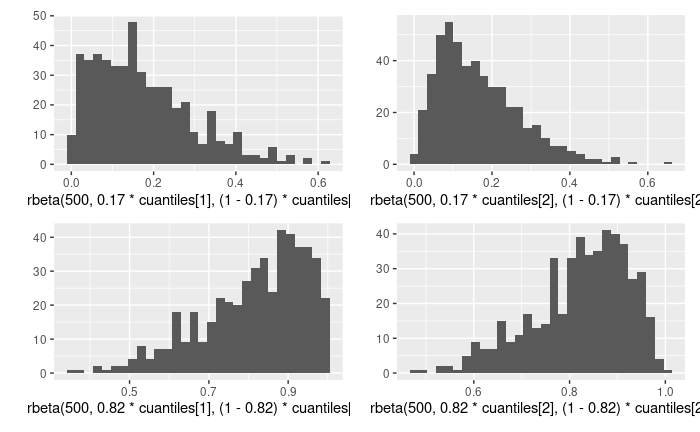

```r
p_1 <- qplot(rbeta(500, 0.17*cuantiles[1], (1-0.17)*cuantiles[1]))
p_2 <- qplot(rbeta(500, 0.17*cuantiles[2], (1-0.17)*cuantiles[2]))
p_3 <- qplot(rbeta(500, 0.82*cuantiles[1], (1-0.82)*cuantiles[1]))
p_4 <- qplot(rbeta(500, 0.82*cuantiles[2], (1-0.82)*cuantiles[2]))
(p_1 + p_2) / (p_3 + p_4)
```

Consideramos todas estas combinaciones como casos límite de posibles resultados, pero creemos que no son extremadamente improbables.

Ahora tenemos que poner una inicial para $\sigma_{est}$. Usaremos
$$\log\sigma_{est(i)} \sim N(0, \sigma)$$

Con $\sigma \sim N^+(0,0.5)$

Verificaremos simulando el ensemble bayesiano y calculando nuestras medidas resumen.

### Simular ensamble bayesiano

```r
set.seed(9913)
prop <- 0.05
## suponemos que la muestra se ha decidido
muestra_tbl <- marco_tbl %>%  group_by(estrato_id) %>%
  mutate(seleccionada = rbinom(n(), 1, prop))
nrow(muestra_tbl %>% filter(seleccionada==1)) / nrow(muestra_tbl)
```

```
[1] 0.05159496
```

```r
muestra <- muestra_tbl %>% filter(seleccionada==1) %>%
  pull(casilla_id)
n <- length(muestra)
n
```

```
[1] 668
```

```r
num_estratos <- length(unique(muestra_tbl$estrato_id))
num_estratos
```

```
[1] 33
```

```r
##
datos_prueba <- list(casilla_id = marco_tbl$casilla_id, est = as.integer(marco_tbl$estrato_id),
                     num_estratos = num_estratos, N = nrow(marco_tbl), nom = marco_tbl$ln,
                     muestra = muestra, n = n)
jsonlite::write_json(datos_prueba, "../datos/datos_prueba.json")
sim_datos <- jsonlite::read_json("../datos/datos_prueba.json", simplifyVector = TRUE)
parametros <- jsonlite::read_json("../datos/datos_inicial.json", simplifyVector = TRUE)
print(parametros)
```

```
$mu_pars
[1]  0.5 10.0

$kappa_pars
[1] 100  10

$sigma_pars
[1] 0.5
```

```r
sim_ensemble_datos <- c(sim_datos, parametros)
ruta <- file.path("../stan/ensemble_modelo.stan")
modelo_inicial <- cmdstan_model(ruta)
```

```
Model executable is up to date!
```

```r
ensemble <- simular_ensemble(modelo_inicial, sim_ensemble_datos, 1500)
```

```
Running MCMC with 1 chain...

Chain 1 Iteration:    1 / 1500 [  0%]  (Sampling)
Chain 1 Iteration: 1500 / 1500 [100%]  (Sampling)
Chain 1 finished in 0.7 seconds.
```

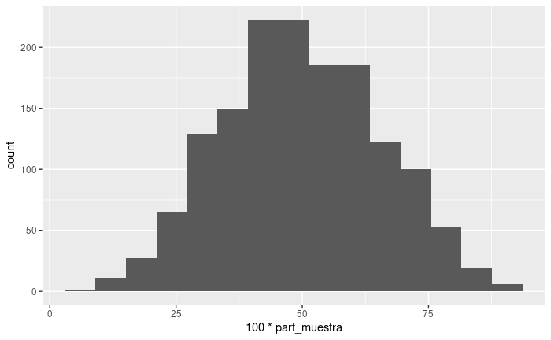

```r
part_tbl <- ensemble$draws(c( "part_muestra", "mu", "kappa")) %>% as_draws_df()
ggplot(part_tbl, aes(x = 100 * part_muestra)) + geom_histogram(bins = 15)
```

Vemos que:

Algunas simulaciones por estrato:

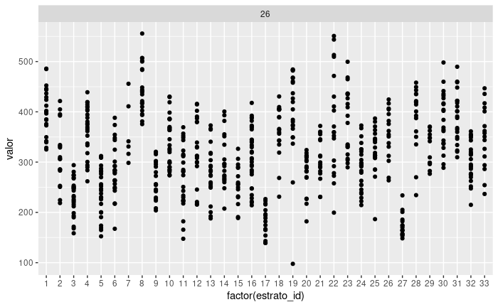

```r
sims_ejemplo_tbl <- ensemble$draws(c("y", "p_est")) %>% as_draws_df %>%
  select(-.iteration, -.chain) %>%
  pivot_longer(-.draw, names_to = "variable", values_to = "valor") %>%
  separate(variable, sep = "[\\[\\]]", into = c("variable", "num", "c")) %>%
  select(-c)
sims_ejemplo_tbl %>%
  filter(variable == "y") %>%
  mutate(estrato_id = sim_ensemble_datos$est[sim_ensemble_datos$muestra][as.integer(num)]) %>%
  filter(.draw == 26) %>%
ggplot(aes(x = factor(estrato_id), y = valor)) +
  geom_point() +
  facet_wrap(~.draw)
```

### Ajustar al ensemble simulado

Ahora veremos si podemos ajustar el modelo al ensemble simulado

```r
num_iter <- 26
ensemble$draws(c("mu", "kappa", "sigma")) %>%
as_draws_df() %>%
  as_tibble() %>% filter(.draw == num_iter)
```

| mu | kappa | sigma | .chain | .iteration | .draw |
| --- | --- | --- | --- | --- | --- |
| 0.591071 | 9.45096 | 0.716659 | 1 | 26 | 26 |

```r
sim_y <- ensemble$draws("y") %>% as_draws_df() %>%
  filter(.draw == num_iter)  %>%
  select(starts_with("y")) %>%
  as.numeric()
```

```r
ruta <- file.path("../stan/modelo.stan")
modelo <- cmdstan_model(ruta)
```

[output not shown]

[output not shown]

[output cut: 25 more lines]

[output not shown]

```r
datos_sim <- c(sim_ensemble_datos, list("y" = sim_y))
ajuste <- modelo$sample(data = datos_sim,
                          seed = 22101,
                          iter_sampling = 1000, iter_warmup = 2000,
                          refresh = 1000, parallel_chains = 4,
                          show_messages = FALSE)
```

```
Running MCMC with 4 parallel chains...

Chain 1 Iteration:    1 / 3000 [  0%]  (Warmup)
Chain 2 Iteration:    1 / 3000 [  0%]  (Warmup)
Chain 3 Iteration:    1 / 3000 [  0%]  (Warmup)
Chain 4 Iteration:    1 / 3000 [  0%]  (Warmup)
Chain 1 Iteration: 1000 / 3000 [ 33%]  (Warmup)
Chain 2 Iteration: 1000 / 3000 [ 33%]  (Warmup)
Chain 3 Iteration: 1000 / 3000 [ 33%]  (Warmup)
Chain 4 Iteration: 1000 / 3000 [ 33%]  (Warmup)
Chain 1 Iteration: 2000 / 3000 [ 66%]  (Warmup)
Chain 1 Iteration: 2001 / 3000 [ 66%]  (Sampling)
Chain 2 Iteration: 2000 / 3000 [ 66%]  (Warmup)
Chain 2 Iteration: 2001 / 3000 [ 66%]  (Sampling)
Chain 3 Iteration: 2000 / 3000 [ 66%]  (Warmup)
Chain 3 Iteration: 2001 / 3000 [ 66%]  (Sampling)
Chain 4 Iteration: 2000 / 3000 [ 66%]  (Warmup)
Chain 4 Iteration: 2001 / 3000 [ 66%]  (Sampling)
Chain 2 Iteration: 3000 / 3000 [100%]  (Sampling)
Chain 2 finished in 4.1 seconds.
Chain 1 Iteration: 3000 / 3000 [100%]  (Sampling)
Chain 3 Iteration: 3000 / 3000 [100%]  (Sampling)
Chain 1 finished in 4.3 seconds.
Chain 3 finished in 4.2 seconds.
Chain 4 Iteration: 3000 / 3000 [100%]  (Sampling)
Chain 4 finished in 4.4 seconds.

All 4 chains finished successfully.
Mean chain execution time: 4.3 seconds.
Total execution time: 4.6 seconds.
```

```r
ajuste
```

| variable | mean | median | sd | mad | q5 | q95 | rhat | ess_bulk | ess_tail |
| --- | --- | --- | --- | --- | --- | --- | --- | --- | --- |
| lp__ | 2504.38 | 2504.75 | 6.10 | 6.22 | 2494.00 | 2513.65 | 1.01 | 1536 | 2561 |
| mu | 0.53 | 0.53 | 0.02 | 0.03 | 0.49 | 0.58 | 1.00 | 6897 | 2718 |
| kappa | 10.87 | 10.83 | 1.02 | 1.03 | 9.24 | 12.61 | 1.00 | 6742 | 3021 |
| sigma | 0.74 | 0.73 | 0.09 | 0.09 | 0.60 | 0.91 | 1.00 | 5566 | 3284 |
| p_est[1] | 0.65 | 0.65 | 0.00 | 0.00 | 0.65 | 0.66 | 1.00 | 5215 | 2864 |
| p_est[2] | 0.59 | 0.59 | 0.00 | 0.00 | 0.58 | 0.59 | 1.00 | 5304 | 2195 |
| p_est[3] | 0.38 | 0.38 | 0.00 | 0.00 | 0.37 | 0.38 | 1.00 | 5736 | 2755 |
| p_est[4] | 0.65 | 0.65 | 0.00 | 0.00 | 0.64 | 0.65 | 1.00 | 5250 | 2715 |
| p_est[5] | 0.42 | 0.42 | 0.00 | 0.00 | 0.41 | 0.42 | 1.00 | 5324 | 2641 |
| p_est[6] | 0.49 | 0.49 | 0.01 | 0.01 | 0.48 | 0.50 | 1.00 | 5724 | 2951 |

```
 # showing 10 of 73 rows (change via 'max_rows' argument)
```

```r
ajuste$cmdstan_diagnose()
```

```
Running bin/diagnose /tmp/RtmpFFNBei/modelo-202010301304-1-0fa161.csv \
  /tmp/RtmpFFNBei/modelo-202010301304-2-0fa161.csv /tmp/RtmpFFNBei/modelo-202010301304-3-0fa161.csv \
  /tmp/RtmpFFNBei/modelo-202010301304-4-0fa161.csv
Processing csv files: /tmp/RtmpFFNBei/modelo-202010301304-1-0fa161.csv, /tmp/RtmpFFNBei/modelo-202010301304-2-0fa161.csv, /tmp/RtmpFFNBei/modelo-202010301304-3-0fa161.csv, /tmp/RtmpFFNBei/modelo-202010301304-4-0fa161.csv

Checking sampler transitions treedepth.
Treedepth satisfactory for all transitions.

Checking sampler transitions for divergences.
No divergent transitions found.

Checking E-BFMI - sampler transitions HMC potential energy.
E-BFMI satisfactory for all transitions.

Effective sample size satisfactory.

Split R-hat values satisfactory all parameters.

Processing complete, no problems detected.
```

Ahora examinamos las participaciones por estratos y nuestra estimación a total:

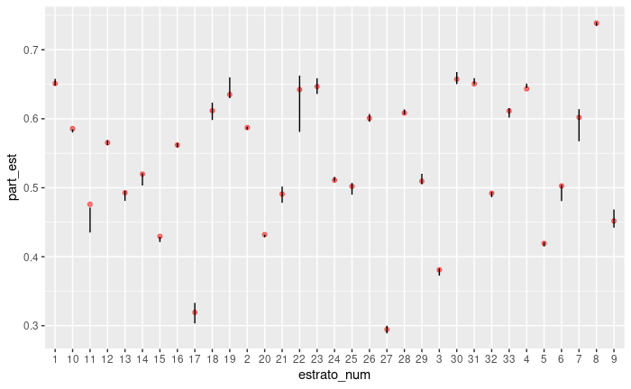

```r
calcular_estratos(ajuste, ensemble) %>%
  ggplot(aes(x = estrato_num, ymin = part_0.05, y = part_est, ymax = part_0.95)) +
    geom_point(colour = "red", alpha = 0.5) +
    geom_linerange()
```

Y finalmente, nuestra estimación es

```r
estimador_final(ajuste)
```

| cuantiles | f |
| --- | --- |
| 0.534 | 0.05 |
| 0.536 | 0.50 |
| 0.538 | 0.95 |

### Ajuste a las observaciones

```r
remesa <- read_delim("../datos/REMESAS0100012200.txt", delim = "|", skip = 1) %>%
  mutate(casilla = ifelse(TIPO_CASILLA %in% c("B", "C"), "B-C", TIPO_CASILLA)) %>%
  unite("id",
        c(iD_ESTADO, SECCION, ID_CASILLA, TIPO_CASILLA, EXT_CONTIGUA), remove = FALSE, sep = "-") %>%
  filter(iD_ESTADO == 9)
muestra_obs <- left_join(remesa, marco_tbl) %>%
  arrange(casilla_id)
datos_stan <- sim_ensemble_datos
y_obs <- pull(muestra_obs, TOTAL)
datos_stan$y <- y_obs %>% as.numeric
datos_stan$n <- length(y_obs)
datos_stan$muestra <- muestra_obs$casilla_id
```

```r
ajuste <- modelo$sample(data = datos_stan,
                          seed = 22101,
                          iter_sampling = 1000, iter_warmup = 2000,
                          refresh = 1000, parallel_chains = 4,
                          show_messages = FALSE)
```

```
Running MCMC with 4 parallel chains...

Chain 1 Iteration:    1 / 3000 [  0%]  (Warmup)
Chain 2 Iteration:    1 / 3000 [  0%]  (Warmup)
Chain 3 Iteration:    1 / 3000 [  0%]  (Warmup)
Chain 4 Iteration:    1 / 3000 [  0%]  (Warmup)
Chain 1 Iteration: 1000 / 3000 [ 33%]  (Warmup)
Chain 2 Iteration: 1000 / 3000 [ 33%]  (Warmup)
Chain 3 Iteration: 1000 / 3000 [ 33%]  (Warmup)
Chain 4 Iteration: 1000 / 3000 [ 33%]  (Warmup)
Chain 1 Iteration: 2000 / 3000 [ 66%]  (Warmup)
Chain 1 Iteration: 2001 / 3000 [ 66%]  (Sampling)
Chain 2 Iteration: 2000 / 3000 [ 66%]  (Warmup)
Chain 2 Iteration: 2001 / 3000 [ 66%]  (Sampling)
Chain 3 Iteration: 2000 / 3000 [ 66%]  (Warmup)
Chain 3 Iteration: 2001 / 3000 [ 66%]  (Sampling)
Chain 4 Iteration: 2000 / 3000 [ 66%]  (Warmup)
Chain 4 Iteration: 2001 / 3000 [ 66%]  (Sampling)
Chain 1 Iteration: 3000 / 3000 [100%]  (Sampling)
Chain 2 Iteration: 3000 / 3000 [100%]  (Sampling)
Chain 1 finished in 2.9 seconds.
Chain 2 finished in 2.9 seconds.
Chain 3 Iteration: 3000 / 3000 [100%]  (Sampling)
Chain 4 Iteration: 3000 / 3000 [100%]  (Sampling)
Chain 3 finished in 2.9 seconds.
Chain 4 finished in 2.9 seconds.

All 4 chains finished successfully.
Mean chain execution time: 2.9 seconds.
Total execution time: 3.0 seconds.
```

```r
ajuste
```

| variable | mean | median | sd | mad | q5 | q95 | rhat | ess_bulk | ess_tail |
| --- | --- | --- | --- | --- | --- | --- | --- | --- | --- |
| lp__ | 952.58 | 952.85 | 6.33 | 6.40 | 941.62 | 962.52 | 1.00 | 1453 | 2510 |
| mu | 0.68 | 0.68 | 0.02 | 0.02 | 0.64 | 0.72 | 1.00 | 7534 | 2999 |
| kappa | 11.52 | 11.49 | 1.07 | 1.08 | 9.80 | 13.29 | 1.00 | 9071 | 2991 |
| sigma | 0.94 | 0.93 | 0.11 | 0.11 | 0.77 | 1.14 | 1.00 | 7257 | 3321 |
| p_est[1] | 0.67 | 0.67 | 0.01 | 0.01 | 0.65 | 0.69 | 1.00 | 5720 | 2578 |
| p_est[2] | 0.73 | 0.73 | 0.01 | 0.01 | 0.72 | 0.75 | 1.00 | 6525 | 2860 |
| p_est[3] | 0.70 | 0.70 | 0.01 | 0.01 | 0.68 | 0.72 | 1.00 | 6061 | 2400 |
| p_est[4] | 0.66 | 0.66 | 0.02 | 0.01 | 0.64 | 0.69 | 1.00 | 5945 | 2793 |
| p_est[5] | 0.66 | 0.66 | 0.02 | 0.02 | 0.63 | 0.68 | 1.00 | 5538 | 2957 |
| p_est[6] | 0.71 | 0.71 | 0.01 | 0.01 | 0.70 | 0.73 | 1.00 | 3629 | 2427 |

```
 # showing 10 of 73 rows (change via 'max_rows' argument)
```

```r
ajuste$cmdstan_diagnose()
```

```
Running bin/diagnose /tmp/RtmpFFNBei/modelo-202010301304-1-a4fab3.csv \
  /tmp/RtmpFFNBei/modelo-202010301304-2-a4fab3.csv /tmp/RtmpFFNBei/modelo-202010301304-3-a4fab3.csv \
  /tmp/RtmpFFNBei/modelo-202010301304-4-a4fab3.csv
Processing csv files: /tmp/RtmpFFNBei/modelo-202010301304-1-a4fab3.csv, /tmp/RtmpFFNBei/modelo-202010301304-2-a4fab3.csv, /tmp/RtmpFFNBei/modelo-202010301304-3-a4fab3.csv, /tmp/RtmpFFNBei/modelo-202010301304-4-a4fab3.csv

Checking sampler transitions treedepth.
Treedepth satisfactory for all transitions.

Checking sampler transitions for divergences.
No divergent transitions found.

Checking E-BFMI - sampler transitions HMC potential energy.
E-BFMI satisfactory for all transitions.

Effective sample size satisfactory.

Split R-hat values satisfactory all parameters.

Processing complete, no problems detected.
```

```r
ajuste
```

| variable | mean | median | sd | mad | q5 | q95 | rhat | ess_bulk | ess_tail |
| --- | --- | --- | --- | --- | --- | --- | --- | --- | --- |
| lp__ | 952.58 | 952.85 | 6.33 | 6.40 | 941.62 | 962.52 | 1.00 | 1453 | 2510 |
| mu | 0.68 | 0.68 | 0.02 | 0.02 | 0.64 | 0.72 | 1.00 | 7534 | 2999 |
| kappa | 11.52 | 11.49 | 1.07 | 1.08 | 9.80 | 13.29 | 1.00 | 9071 | 2991 |
| sigma | 0.94 | 0.93 | 0.11 | 0.11 | 0.77 | 1.14 | 1.00 | 7257 | 3321 |
| p_est[1] | 0.67 | 0.67 | 0.01 | 0.01 | 0.65 | 0.69 | 1.00 | 5720 | 2578 |
| p_est[2] | 0.73 | 0.73 | 0.01 | 0.01 | 0.72 | 0.75 | 1.00 | 6525 | 2860 |
| p_est[3] | 0.70 | 0.70 | 0.01 | 0.01 | 0.68 | 0.72 | 1.00 | 6061 | 2400 |
| p_est[4] | 0.66 | 0.66 | 0.02 | 0.01 | 0.64 | 0.69 | 1.00 | 5945 | 2793 |
| p_est[5] | 0.66 | 0.66 | 0.02 | 0.02 | 0.63 | 0.68 | 1.00 | 5538 | 2957 |
| p_est[6] | 0.71 | 0.71 | 0.01 | 0.01 | 0.70 | 0.73 | 1.00 | 3629 | 2427 |

```
 # showing 10 of 73 rows (change via 'max_rows' argument)
```

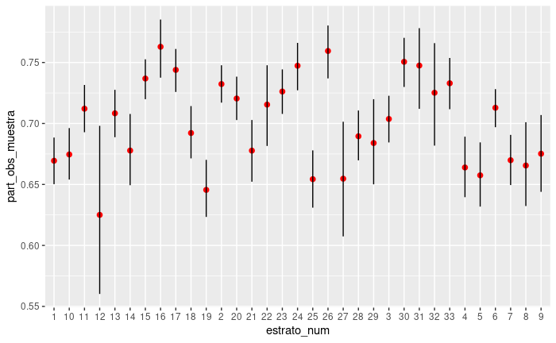

```r
prop_obs_tbl <- muestra_obs %>%
  group_by(estrato_id) %>%
  summarise(part_obs_muestra = sum(TOTAL) / sum(LISTA_NOMINAL)) %>%
  mutate(estrato_num = as.character(estrato_id))
calcular_estratos(ajuste) %>%
  left_join(prop_obs_tbl) %>%
  ggplot(aes(x = estrato_num, ymin = part_0.05, y = part_obs_muestra, ymax = part_0.95)) +
  geom_point(colour = "red", size = 2) +
  geom_linerange()
```

```r
estimador_final(ajuste)
```

| cuantiles | f |
| --- | --- |
| 0.696 | 0.05 |
| 0.701 | 0.50 |
| 0.706 | 0.95 |

En general observamos sobredispersión con respecto al modelo binomial:

```r
media_exp <- function(x) mean(exp(x))
ajuste$draws("log_sigma_est") %>% as_draws_df() %>%
  select(starts_with("log_sigma")) %>%
  summarise(across(everything(), media_exp)) %>%
  pivot_longer(everything())
```

| name | value |
| --- | --- |
| log_sigma_est[1] | 2.193473 |
| log_sigma_est[2] | 1.787471 |
| log_sigma_est[3] | 2.481596 |
| log_sigma_est[4] | 2.569518 |
| log_sigma_est[5] | 2.735918 |
| log_sigma_est[6] | 1.245162 |
| log_sigma_est[7] | 2.368579 |
| log_sigma_est[8] | 3.082917 |
| log_sigma_est[9] | 3.840647 |
| log_sigma_est[10] | 1.529774 |

[output cut: 23 more lines]

### Verificación posterior dentro de muestra

### Siguientes pasos

- Calibración inferencial
- Agregar casillas especiales (que no tienen lista nominal)
- Verificación posterior a nivel casilla